# Dateset Overview:

# Contextual Data:

The following are three contextal data visualization that provide more information in analzing the sanitary condition of Chicago food stations. The first one describes the pass and fail numbers of all inspections. The second one is three risk level numbers of all inspections. The third one is inspection number by zip code. This three visualizations can help us to better understand the overall inspection result of the Chicago food stations. And inspection by zip code will provide more detail for us to refine visualization in the map.

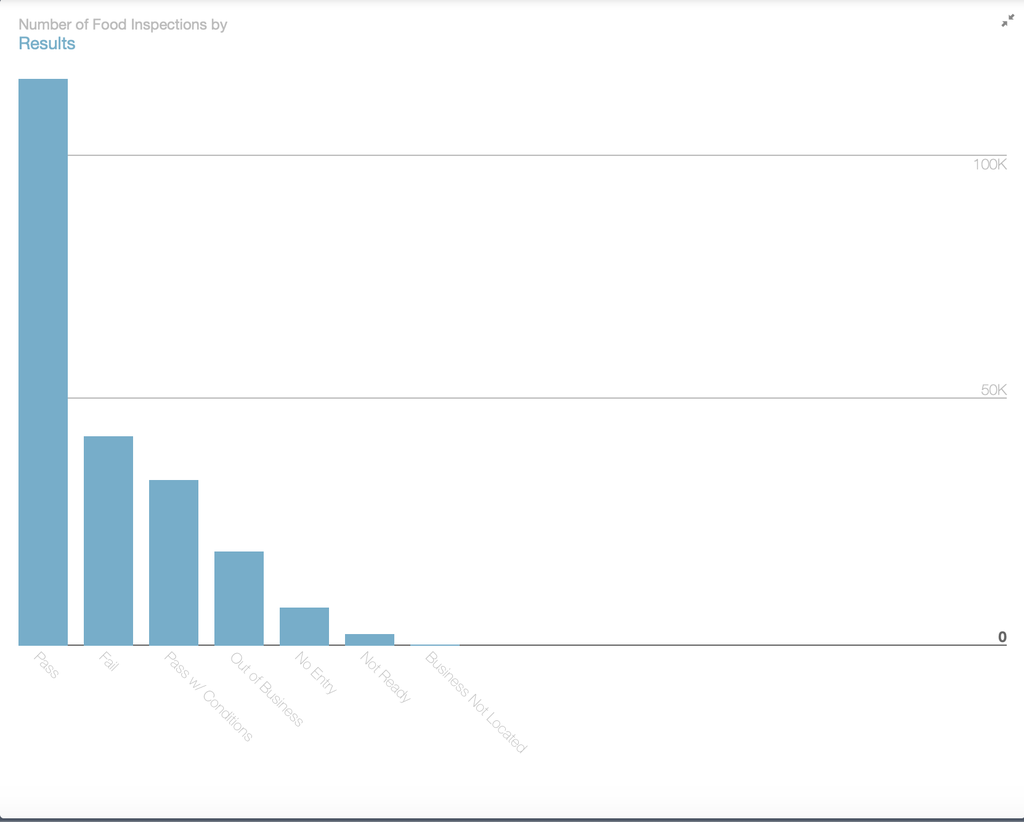

```python
path_to_image_1 = '/Users/yifanhu/Desktop/pass_fail.png'
im_1 = Image.open(path_to_image_1)
im_1
```

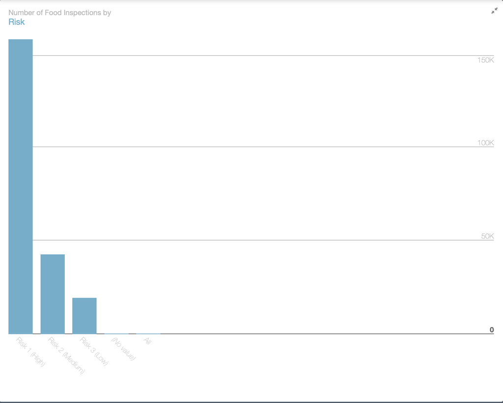

```python
path_to_image_2 = '/Users/yifanhu/Desktop/risk_level.png'
im_2 = Image.open(path_to_image_2)
im_2
```

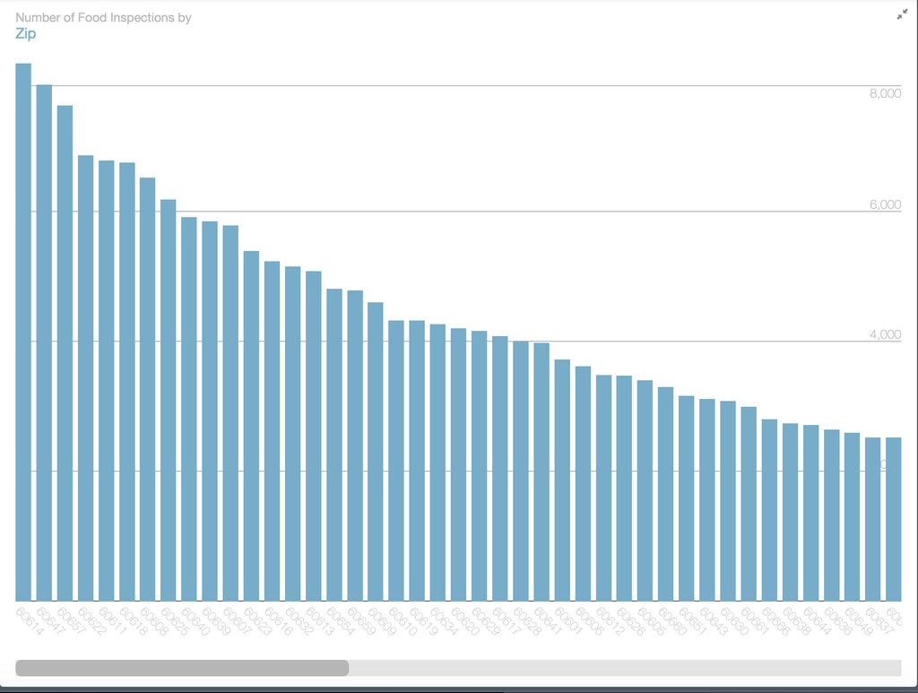

```python
path_to_image_3 = '/Users/yifanhu/Desktop/zip_inspection.png'
im_3 = Image.open(path_to_image_3)
im_3
```

# Reference link:

Dataset: https://uofi.box.com/shared/static/5637axblfhajotail80yw7j2s4r27hxd.csv Contextual Visualization: https://data.cityofchicago.org/Health-Human-Services/Food-Inspections-Dashboard/2bnm-jnvb Other reference link: https://www.kaggle.com/chicago/chicago-food-inspections